# Benefício fiscal ao setor atacadista do Rio de Janeiro: medindo via controle sintético os resultados obtidos pelo Espirito Santo

Ibsen Melo

11/26/2020

## Introdução

Diversos estados brasileiros adotaram a guerra fiscal como forma de atrair mais empresas. A guerra fiscal, de forma simplificada, seria uma redução de impostos visando atrair empresas. Embora a redução da carga tributária possa levar a uma redução da arrecadação, alguns argumentam que, ao atrair mais empresas, o estado arrecadaria mais pela maior quantidade de empresas. Contudo, a guerra fiscal entre os estados existam há mais de uma década e os estudos são escassos nessa área.

Em 2020 houve um debate sobre o projeto de Lei 2772/20 ( conforme [DOERJ 10/08/2020](http://www.ioerj.com.br/portal/modules/conteudoonline/mostra_edicao.php?session=VW10VmVGSnFRWGxSVlZWMFRrUktSbEpwTURCTmExazBURlJuZUUxcVZYUk5WRVY1VDBSa1FrNVZXa1pOUkVrMQ==), [DOERJ 18/08/2020](http://www.ioerj.com.br/portal/modules/conteudoonline/mostra_edicao.php?session=VG5wRk1VMVVXVE5PUkZsMFVrUmplRTU1TURCT1JWSkdURlZGTWsxVlNYUk9SVVUxVDFSVk1FNTZSVE5OVkVwQw==) e [DOERJ 03/09/2020](http://www.ioerj.com.br/portal/modules/conteudoonline/mostra_edicao.php?session=VFdwT1IwNXFXVEpPTUVWMFVsUkNSazU1TURCT2FrMHlURlJuTlU5RVVYUlNhMWt6VW1wc1EwNVVTVE5PVkU1RFRWUlZOVTlVU1hwT2VrRTFUbmM5UFE9PQ==)) que após aprovado se tronou a Lei 9025/20. Tal lei versa sobre benefício fiscal para o setor atacadista do Rio de Janeiro e foi inspirada na Lei 10.568/16 do Espirito Santo (ES).

Visando gerar maior competitividade para o setor atacadista do Espirito Santo, o Governo local publicou a Lei 10.568/16, conhecida como COMPETE/ES. Tal lei prevê benefícios fiscais para o setor atacadista. Um destes benefícios é a redução da carga tributária do ICMS para 1,1% quando o estabelecimento efetuar saídas interestaduais. Atualmente a alíquota interestadual do ICMS é de 12% ou 7%, dependendo do caso.

Tendo em vista que o benefício fiscal aprovado pelo governo do RJ já está em utilização no ES, neste estudo procuramos avaliar os impactos gerados na economia capixaba.

## Métodos

Como a Lei 10.568/16 foi publicada em julho de 2016 mas recebeu diversas alterações naquele mesmo ano(Lei 10574 de 17/08/2016 e Lei 10587 de 03/11/2016) adotou-se janeiro de 2017 como início dos efeitos da referida lei, do ponto de vista econômico.

As variáveis observadas foram a arrecadação de ICMS, o nível de desemprego e a produção industrial. A variável nível de desemprego foi obtida por consulta aos dados do Banco Central (BCB), a variável arrecadação foi obtida em consulta ao Ministério da Fazenda (MF/Cotepe) e a variãvel produção industrial foi obtida do IBGE, dados da pesquisa industrial mensal - produção física - divulgação regional.

O metodo utilizado para medir o impacto foi o de controle sintético. Tal método é um dos mais modernos para avaliação de políticas públicas (vide [ipea](https://www.ipea.gov.br/portal/images/stories/PDFs/livros/livros/181009_politicas_publicas_no_brasil_cap12.pdf) e [FGV/IBRE](https://blogdoibre.fgv.br/posts/recessao-brasileira-2014-2016-uma-analise-por-meio-do-metodo-do-controle-sintetico-do-pib-pib)). O método do controle sintético busca criar uma nova versão “sintética” da variável em estudo. Ele utiliza a observação da mesma variável em unidades de controle, ou seja, que não foram submetidas à intervenção e tenta recriar a variável observada no indivíduo submetido à determinada política pública.

```r
library(tidyverse)
library(gsynth)
library(BETS)
```

## Arrecadação

```r
# baixando, tratando e salvando os dados

data <-"2010-01-01" # data inicial


acre <- BETSget(4326, from = data)
alagoas <- BETSget(4333, from = data)
amapa <- BETSget(4327, from = data)
amazonas <- BETSget(4328, from = data)
bahia <- BETSget(4334, from = data)
ceara <- BETSget(4335, from = data)
df <- BETSget(4349, from = data)
es <- BETSget(4342, from = data)
goias <- BETSget(4350, from = data)
maranhao <- BETSget(4336, from = data)
mt <- BETSget(  4351, from = data)
ms <- BETSget(4352, from = data)
mg <- BETSget(4343, from = data)
para <- BETSget(4329, from = data)
pb <- BETSget(4337, from = data)
parana <- BETSget(4346, from = data)
pe <- BETSget(4338, from = data)
piaui <- BETSget(4339, from = data)
rj <- BETSget(4344, from = data)
rn <- BETSget(4340, from = data)
rs <- BETSget(4347, from = data)
rondonia <- BETSget(4330, from = data)
rr <- BETSget(4331, from = data)
sc <- BETSget(4348, from = data)
sp <- BETSget(4345, from = data)
sergipe <- BETSget(4341, from = data)
tocantins <- BETSget(4332, from = data)



icms_uf <- ts.union(acre, alagoas, amapa, amazonas, bahia, ceara, df ,
                    es, goias, maranhao, mt, ms, mg, para, pb, parana,
                    pe, piaui, rj, rn, rs, rondonia, rr, sc, sp, sergipe, tocantins)



dado <- as.data.frame(icms_uf)

dado$data <- seq(as.Date(data), by = "month", length.out = nrow(dado))

dado1 <- pivot_longer(dado,cols = acre:tocantins, names_to = "estado")

dado1$treated <- ifelse(dado1$data > "2016-12-01" & dado1$estado == "es",1,0)

write_csv2(dado1,"icms_uf.csv")
```

```r
dado1 <- read_csv2("icms_uf.csv")
```

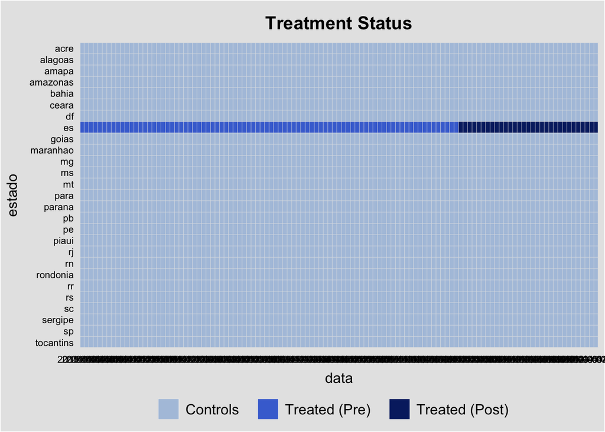

```r
library(panelView)


panelView(value ~ treated, data = dado1,  index = c("estado","data"), pre.post = TRUE)
```

```r
out_ar <- gsynth(value ~ treated, data = dado1,  index = c("estado","data"),
              force = "two-way", CV = TRUE, r = c(1, 4), se = TRUE,
              inference = "parametric", nboots = 1000, parallel = FALSE)
```

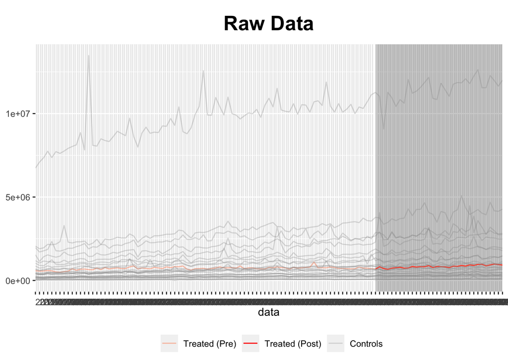

```r
plot(out_ar, type = "raw", theme.bw = F)
```

Acima estão os dados da arrecadação de ICMS dos estados. O maior valor que se destaca dos demais é o estado de São Paulo. A segunda maior arrecadação é o estado de Minas Gerais e o RJ está em terceiro. Mas por algum motivo de difícil compreensão o estado do Rio de Janreiro está usando o ES como referência.

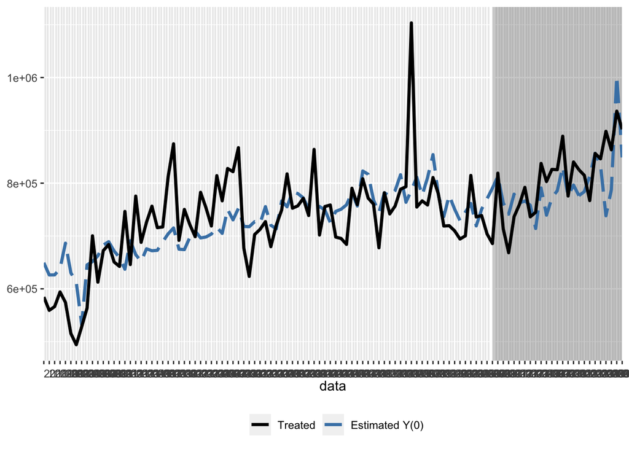

```r
plot(out_ar, type = "counterfactual", raw = "none", main="", xlim = c(1,108))
```

No gráfico acima é possível ver o resultado do controle sintético. A linha preta representa a arrecadação do ES. A linha azul representa o contrafactual, o controle sintetico gerado pelo modelo. A área cinza escura representa o período após o evento. Pelo gráfico podemos dizer que a arrecadação do estado não apresentou mudanças após o início do benefício fiscal. As linhas azul e preta continuam andando muito próximas. Portanto, não houve perda nem ganho de arrecadação.

## Emprego

```r
library(Quandl)

df.search <- Quandl.search("'rio de janeiro'",
                           silent = TRUE,
                           per_page = 200)
```

```r
# baixando, tratando e salvando os dados de desemprego

library(Quandl)

data <- "2010-01-01"

desemprego_es <- Quandl("BCB/12781", type="ts", start_date=data)
desemprego_rj <- Quandl("BCB/12779", type="ts", start_date=data)
desemprego_pe <- Quandl("BCB/12640", type="ts", start_date=data)
desemprego_ap <- Quandl("BCB/12538", type="ts", start_date=data)
desemprego_am <- Quandl("BCB/12539", type="ts", start_date=data)
desemprego_pa <- Quandl("BCB/12540", type="ts", start_date=data)
desemprego_ro <- Quandl("BCB/12541", type="ts", start_date=data)
desemprego_rr <- Quandl("BCB/12542", type="ts", start_date=data)
desemprego_to <- Quandl("BCB/12543", type="ts", start_date=data)
desemprego_pr <- Quandl("BCB/12615", type="ts", start_date=data)
desemprego_pb <- Quandl("BCB/12641", type="ts", start_date=data)
desemprego_al <- Quandl("BCB/12643", type="ts", start_date=data)
desemprego_se <- Quandl("BCB/12644", type="ts", start_date=data)
desemprego_ma <- Quandl("BCB/13142", type="ts", start_date=data)
desemprego_pi <- Quandl("BCB/13143", type="ts", start_date=data)
desemprego_ce <- Quandl("BCB/13141", type="ts", start_date=data)
desemprego_sc <- Quandl("BCB/12622", type="ts", start_date=data)
desemprego_sp <- Quandl("BCB/12868", type="ts", start_date=data)
desemprego_rn <- Quandl("BCB/12642", type="ts", start_date=data)
desemprego_rs <- Quandl("BCB/13103", type="ts", start_date=data)




desmprego <- ts.union(
  desemprego_es,
desemprego_rj ,
desemprego_pe,
desemprego_ap,
desemprego_am,
desemprego_pa,
desemprego_ro,
desemprego_rr,
desemprego_to,
desemprego_pr,
desemprego_pb,
desemprego_al,
desemprego_se,
desemprego_ma,
desemprego_pi,
desemprego_ce,
desemprego_sc,
desemprego_sp,
desemprego_rn,
desemprego_rs
)

desemprego <- as.data.frame(desmprego)

desemprego$data <- seq(as.Date(data), by = "month", length.out = nrow(desemprego))

desemprego <- pivot_longer(desemprego, cols = desemprego_es:desemprego_rs, names_to = "estado")

desemprego$treated <- ifelse(desemprego$data > "2016-12-01" & desemprego$estado == "desemprego_es",1,0)

# retirando estados que não possuem dados completos

retirar <- unique(desemprego$estado[is.na(desemprego$value)])

desemprego <- desemprego[!(desemprego$estado %in% retirar),]

write_csv2(desemprego,"desemprego.csv")
```

```r
desemprego <- read_csv2("desemprego.csv")
```

```r
out <- gsynth(value ~ treated, data = desemprego,  index = c("estado","data"),
              force = "two-way", CV = TRUE, r = c(1, 4), se = TRUE,
              inference = "parametric", nboots = 1000, parallel = TRUE)
```

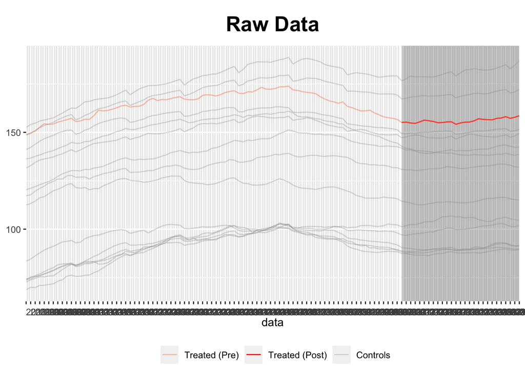

```r
plot(out, type = "raw", theme.bw = F)
```

Acima, o indice de desemprego dos estados no período de janeiro de 2010 a dezembro de 2018. Em vermelho o estado do Espirito Santo. Foram utilizados dados mensais de janeiro de 2010 a dezembro de 2018.

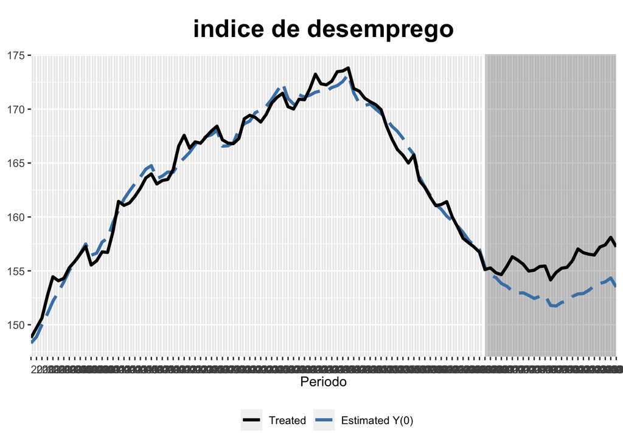

```r
plot(out, type = "counterfactual", raw = "none", xlab = "Periodo", main = "indice de desemprego",xaxt="none",xlim = c(1,108))
```

Neste gráfico observamos o resultado da aplicação do método do controle sintético. Neste caso fica claro que há um descolamento entre o indice real de desemprego e o contrafactual no período após o início do benefício fiscal. Ou seja, o nível de desemprego ficou acima do esperado. Embora ausente de significância estatística, a vigência do benefício fiscal parece ter aumentado o nível de desemprego, com a variação chegando muitas vezes a mais de 3 pontos.

Os resultados apurados parecem sugerir que outros setores podem ter arcado com os custos do benefício. Ao fortalecer o setor atacadista pode ter ocorrido um enfraquecimento do setor industrial. Supondo que em alguns casos a indústria venham a competir pelo mesmo mercado (o mercado interestadual, por exemplo), o atacado passa a ter uma vantagem competitiva via menores custos. Para a indústria continuar vendendo para outros estados vai precisar vender via atacado, induzindo uma espécie de oligopsônio para a indústria local. O setor atacadista do ES já possuia benefício fiscal nas operações internas decorrente da Lei nº 7.000/2001, art. 5-A, inc. VII, trazendo vantagem em relação à industria no mercado interno.

## Industria

```r
library(readxl)
tab2 <- read_xlsx("tabela3653.xlsx", skip = 3)

tab2 <- tab2[-c(1,227,228),-14]

colnames(tab2)[1] <- 'data'

data <- "2002-01-01"

tab2$data <- seq(as.Date(data), by = "month", length.out = nrow(tab2))

tab2 <- pivot_longer(tab2,cols = Amazonas:Goiás, names_to = "estado")

tab2$value <- as.double(tab2$value)
```

```r
tab2$treated <- ifelse(tab2$data > "2016-12-01" & tab2$estado == "Espírito Santo",1,0)
#tab2$treated <- ifelse(tab2$data > "2016-12-01" & tab2$estado == "Rio de Janeiro",1,0)
```

```r
out2 <- gsynth(value ~ treated, data = tab2,  index = c("estado","data"),
              force = "two-way", CV = TRUE, r = c(1, 4), se = TRUE,
              inference = "parametric", nboots = 1000, parallel = TRUE)
```

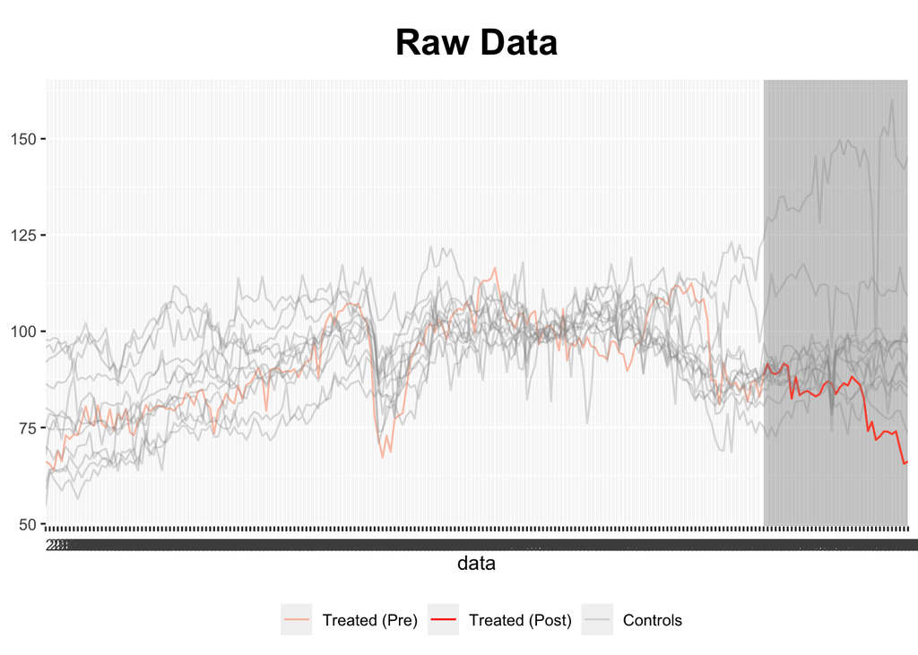

```r
plot(out2, type = "raw", theme.bw = F, xlim = c(1,216))
```

Acima os dados da produção indústrial dos estados sem tratamento estatístico prévio. A linha laranja representa o ES. Foram utilizados dados mensais de janeiro de 2002 a dezembro de 2019.

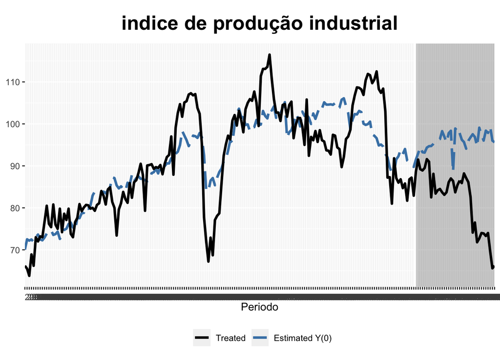

```r
plot(out2, type = "counterfactual", raw = "none", xlab = "Periodo", main = "indice de produção industrial", xlim = c(1,216))
```

No gráfico acima observa-se o resultado da aplicação do modelo de controle sintético. Após o evento, o *gap* entre a produção real e seu contrafactual apenas aumenta com o passar do tempo. Tal evento pode ser o motivo do aumento no nível de desemprego no ES.

```r
tab1 <- read_delim("tabela_ind_estados.csv", ";")

knitr::kable(na.exclude(tab1))
```

| estados | Variação percentual acumulada no ano (Base: igual período do ano anterior) | Variação percentual acumulada nos últimos 12 meses (Base: últimos 12 meses anteriores) | Variação percentual mensal (Base: igual mês do ano anterior) | Variação percentual mês/mês imediatamente anterior com ajuste sazonal (Base: mês imediatamente anterior) |
| --- | --- | --- | --- | --- |
| Amazonas | 4.3 | 4.3 | 12.3 | -1.2 |
| Bahia | -2.5 | -2.5 | -4.1 | -2.0 |
| Brasil | -1.1 | -1.1 | -1.3 | -0.6 |
| Ceará | 1.6 | 1.6 | 4.0 | -2.1 |
| Espírito Santo | -15.1 | -15.1 | -22.8 | 0.9 |
| Goiás | 2.8 | 2.8 | -3.5 | -1.8 |
| Mato Grosso | -3.6 | -3.6 | -10.8 | -12.5 |
| Minas Gerais | -5.6 | -5.6 | -13.9 | -3.7 |
| Nordeste | -2.7 | -2.7 | 4.3 | 0.9 |
| Paraná | 5.7 | 5.7 | 2.4 | 5.4 |
| Pará | -1.1 | -1.1 | 1.4 | 2.5 |
| Pernambuco | -2.2 | -2.2 | -0.4 | -1.6 |
| Rio Grande do Sul | 2.5 | 2.5 | -1.7 | -2.2 |
| Rio de Janeiro | 2.2 | 2.2 | 4.1 | -4.1 |
| Santa Catarina | 2.3 | 2.3 | 1.4 | -0.3 |
| São Paulo | 0.0 | 0.0 | -2.3 | -1.1 |

Acima, tabela com dados do IBGE sobre a produção industrial dos estados em dezembro de 2019. Nele, o ES apresenta o pior resultado, apresentando uma redução de 15,1% em sua produção industrial no ano de 2019 quando comparado ao ano de 2018. Possívelmente, a maior parte das mercadorias adquiridas pelo setor atacadista vem de fora do estado.

## conclusão

O presente caso parece ser mais um exemplo de “rent seeking”, situação na qual um grupo exerce pressão para obter maior fatia na riqueza existente na sociedade, sem que a ação gere aumento de riqueza. Conforme artigo de [James Bessen](https://hbr.org/2016/05/lobbyists-are-behind-the-rise-in-corporate-profits) as grandes empresas obtem boa parte de seus lucros através de lobby político para obter vantagens legislativas. Segundo [Leandro Narloch](https://www.mises.org.br/Article.aspx?id=2809), para o “rent seeking” funcionar o discurso é fundamental. Neste ponto é inserida uma justificativa que faça o interesse privado parecer interesse público. Quando o assunto é benefício fiscal os argumentos mais utilizados são que vai atrair mais empresas, gerar mais empregos (esse é o mais usado), atrair investimentos, entre outros.

O outro ponto é que a Lei capixaba traz alguns benefícios para setores industriais específicos. Apesar disso, o ES sofre uma forte desindustrialização. A versão fluminense não comtempla nenhum setor industrial. Isto leva a crer que o impacto poderá ser maior na indústria fluminense gerando maior desemprego, pois o desemprego gerado em outros setores parece superar os empregos gerado no setor atacadista.